# Open Access Soldagem & Inspeção

Publicação de: **Associação Brasileira de Soldagem**  
Área: Engenharias Versão impressa ISSN: 0104-9224  
Versão on-line ISSN: 1980-6973

- [Submissão de manuscritos](http://mc04.manuscriptcentral.com/si-scielo)
- Sobre o periódico
- Corpo Editorial
- Instruções aos autores

(Atualizado: 28/11/2024)

# Sobre o periódico

**Informações básicas**

[output not shown]

**Open Access & Propriedade Intelectual**

[output not shown]

**Fontes de indexação**

- Science Citation Index Expanded - SCIE
- Materials Science Citation Index (Thomson Scientific) - MSCI
- Journal Citation Reports/Science Edition (Thomson Scientific) - JCR
- Energy Technology Data Exchange - ETDE
- WELDASERCH (The Welding Institute)
- Metals Abstracts - METADEX
- Engineered Materials Abstracts
- Corrosion Abstracts
- Aluminum Industry Abstracts (CSA)
- Qualis
- SCOPUS
- Essencial Science Indicators
- EBSCO
- LATINDEX

**Financiamento**

A publicação recebe financiamento de:

- [Associação Brasileira de Soldagem - ABS](http://www.abs-soldagem.org.br)
- [Conselho Nacional de Desenvolvimento Científico e Tecnológico - CNPq](http://www.cnpq.br)
- [Coordenação de Aperfeiçoamento de Pessoal de Nível Superior - CAPES](http://www.capes.gov.br/)

# Corpo editorial

**Editores-chefes**

- Hélio Cordeiro de Miranda, Universidade Federal do Ceará (UFC), Fortaleza, Ceará, CE, Brasil, hmiranda@ufc.br – ID Lattes: 6420338928006265 – ORCID: 0000-0003-2699-4333
- Cleiton Carvalho Silva, Universidade Federal do Ceará (UFC), Fortaleza, Ceará, CE, Brasil, cleiton@metalmat.ufc.br – ID Lattes: 2862541276328123 – ORCID: 0000-0001-6827-8939

**Editores associados**

- Alexandre Queiroz Bracarense, Universidade Federal de Minas Gerais (UFMG), Belo Horizonte, Minas Gerais, MG, Brasil - ID Lattes: 0723315222598414– ORCID: 0000-0001-7326-497X
- Altino Loureiro, Universidade de Coimbra, Coimbra, Portugal – ORCID: 0000-0001-9315-3177
- Américo Scotti, Universidade Federal de Uberlândia (UFU), Uberlândia, Minas Gerais, MG, Brasil – ID Lattes: 5719116057125057 – ORCID: 0000-0002-1005-5895
- Ana Sofia Clímaco Monteiro d'Oliveira, Universidade Federal do Paraná (UFPR), Curitiba, Paraná, PR, Brasil – ID Lattes: 3779022347677794 – ORCID: 0000-0002-9736-6652
- Gianni Campatelli, University of Firenze, Firenze, Itália – ORCID: 0000-0002-9699-1368
- Hernán Gabriel Svoboda, Universidad de Buenos Aires (UBA), Buenos Aires, Argentina – ORCID: 0000-0001-7539-8306
- José Antônio Esmerio Mazzaferro, Universidade Federal do Rio Grande do Sul (UFRGS), Porto Alegre, Rio Grande do Sul, RS, Brasil – ID Lattes: 3793292178532740 – ORCID: 0000-0002-8042-5695
- Louriel Vilarinho, Universidade Federal de Uberlândia (UFU), Uberlândia, Minas Gerais, MG, Brasil – ID Lattes: 8553716610264673 – ORCID: 0000-0002-3914-156X
- Moataz Attallah, University of Birmingham, Birmingham, Inglaterra – ORCID: 0000-0002-7074-9522
- Paulo José Modenesi, Universidade Federal de Minas Gerais (UFMG), Belo Horizonte, Minas Gerais, MG, Brasil – ID Lattes: 6870721499762912 – ORCID: 0000-0002-2990-1625
- Régis Henrique Gonçalves e Silva, Universidade Federal de Santa Catarina (UFSC), Florianópolis, Santa Catarina, SC, Brasil – ID Lattes: 7900356071046936 – ORCID: 0000-0003-0660-6495
- Sebastian Zappa, Universidad Nacional de Lomas de Zamora, Buenos Aires, Argentina – ORCID: 0000-0002-4584-3314
- Stephen Chuen, Colorado School of Mines, Golden - Colorado, Estados Unidos
- Tiago Vieira da Cunha, Universidade Federal de Santa Catarina (UFSC), Joinville, Santa Catarina, SC, Brasil, t.cunha@ufsc.br – ID Lattes: 8049338058151678 – ORCID: 0000-0002-1411-0505

**Revisores do ano de 2022**

A Revista Soldagem & Inspeção expressa sinceros agradecimentos aos profissionais que voluntariamente participaram do processo de avaliação dos manuscritos, com a realização de revisão dos trabalhos submetidos à revista ao longo do ano de 2022. Reconhecemos e valorizamos o esforço e a dedicação demonstrados por cada um, que desempenharam um papel crucial na promoção e no avanço da pesquisa científica na área da soldagem.

As revisões minuciosas, as análises criteriosas e os comentários construtivos que vocês forneceram não apenas ajudaram a aprimorar a qualidade dos artigos, mas também enriqueceram o conteúdo intelectual disponível em nossa revista. A vossa dedicação ao atuar como revisores não apenas beneficia os autores, mas também tem um impacto duradouro na comunidade da soldagem em nível nacional e internacional. Além disso, as análises rigorosas ajudam a garantir a disseminação de pesquisas confiáveis e relevantes, influenciando positivamente a evolução da tecnologia da soldagem e, por consequência, contribuindo para o avanço de setores vitais em diversos países.

Esperamos continuar contando com a vossa colaboração e esperamos que, juntos, possamos continuar a promover avanços notáveis na área da soldagem.

- Agustín Gualco, Consejo Nacional de Investigaciones Cientificas y Tecnicas – Buenos Aires, Argentina
- Américo Scotti, Universidade Federal de Uberlândia – UFU, Uberlândia, Brasil
- Ana María Arizmendi Morquecho, Centro de Investigación en Materiales Avanzados S.C. – Apodaca, Mexico
- Anderson Geraldo Marenda Pukasiewicz, Universidade Tecnológica Federal do Paraná – UTFPR, Ponta Grossa, Brasil
- André Gustavo de Sousa Galdino, Instituto Federal do Espírito Santo – Vitoria, Brasil
- Andrés Mauricio Moreno Uribe, Universidade Federal de Minas Gerais – UFMG, Belo Horizonte, Brasil
- Anil Kumar Deepati, Jazan University – Jizan, Saudi Arabia
- Arnaldo Ruben Gonzalez, Universidade Federal do Rio Grande do Sul – UFRGS, Porto Alegre, Brasil
- Ayrton de Sá Brandim, Instituto Federal de Educação Ciência e Tecnologia do Piauí –Teresina, Brasil
- Camila Pereira Alvarães, Centro Federal de Educação Tecnológica Celso Suckow da Fonseca – Rio de Janeiro, Brasil
- Carmem Nascimento, Instituto Federal de Educação Ciência e Tecnologia do Maranhão – São Luís, Brasil
- Cintia Mazzaferro, Universidade Federal do Rio Grande do Sul – UFRGS, Porto Alegre, Brasil
- Cláudio Turani Vaz, Centro Federal de Educação Tecnológica – CEFET MG, Belo Horizonte, Brasil
- Cleber Marques, Universidade Federal de Santa Catarina – UFSC, Florianópolis, Brasil
- Daniela Fátima Giarollo, Universidade Federal do Rio Grande do Sul – UFRGS, Porto Alegre, Brasil
- Danielle Bond, Universidade do Estado de Santa Catarina – UDESC, Joinville, Brasil
- Douglas Bezerra de Araújo, Universidade Federal de Uberlândia – UFU, Uberlândia, Brasil
- Eduardo Diaz Cedré, Fabricación y Tecnología en Soldadura S.A QUERETARO, Mexico
- Émerson Mendonça Miná, Universidade Federal do Ceara – UFC, Fortaleza, Brasil
- Etiene Pereira Andrade, Universidade Federal de Minas Gerais – UFMG, Belo Horizonte, Brasil
- Fabiano Ramos, Instituto Federal do Rio Grande do Sul – IFRS, Caxias do Sul, Brasil
- Fábio Luis Knewitz, Instituto Federal de Educação Ciência e Tecnologia do Rio Grande do Sul – Bento Goncalves, Brasil
- Francisco Werley Cipriano Farias, Universidade Federal do Rio de Janeiro – UFRJ, Rio de Janeiro, Brasil
- Frank Mello Liberato, Universidade Federal de Minas Gerais – UFMG, Belo Horizonte, Brasil
- Gabriel Mendes de Almeida Carvalho, Universidade Federal de Minas Gerais – UFMG, Belo Horizonte, Brasil
- Guilherme Lemos, Universidade Federal de Santa Maria – UFSM, Santa Maria, Brasil
- Gustavo Bavaresco Sucharski, Universidade Federal do Paraná – UFPR, Curitiba, Brasil
- Hector Costa, Centro Federal de Educacao Tecnologica Celso Suckow da Fonseca – Rio de Janeiro, Brasil
- Hernan Svoboda, Universidad de Buenos Aires – Buenos Aires, Argentina
- Huseyin Gokce, Cankiri Karatekin University – Çankırı, Turkey
- Jorge Carlos Ferreira Jorge, Centro Federal de Educação Tecnológica – CEFET RJ, Rio de Janeiro, Brasil
- José Gedael Fagundes, Universidade Estadual Paulista – UNESP, Ilha Solteira, Brasil
- José Mauro Moraes Junior, Universidade Federal Fluminense – Niterói, Brasil
- Kaio Campo, Universidade Estadual de Campinas – UNICAMP, Campinas, Brasil
- Leonardo Barbosa Godefroid, Universidade Federal de Ouro Preto – Ouro Preto, Brasil
- Luiz Eduardo dos Santos Paes, Universidade Federal de Uberlândia – UFU, Uberlândia, Brasil
- Luiz Henrique Soares Barbosa, Universidade Federal dos Vales do Jequitinhonha e Mucuri – UFVJM, Janaúba, Brasil
- Marcio Correa De Carvalho, Universidade Federal do Sul e Sudeste do Para – Marabá, Brasil
- Marcos Dorigão Manfrinato, FATEC Sorocaba – Sorocaba, Brasil
- Marcus Vinícius Volponi Mortean, Universidade Federal de Santa Catarina – UFSC, Florianópolis, Brasil
- Mauricio Neves, Instituto de Pesquisas Energéticas e Nucleares – São Paulo, Brasil
- Mehmet Akif Erden, Karabuk University – Karabuk, Turkey
- Paulo J. Modenesi, Universidade Federal de Minas Gerais – UFMG, Belo Horizonte, Brasil
- Regina Garcia, Brasil
- Rodolfo Lisboa Batalha, Instituto de Soldadura e Qualidade – Porto Salvo, Portugal
- Roger Navarro Verástegui, Universidade Tecnológica Federal do Paraná – UTFPR, Ponta Grossa, Brasil
- Sebastian Zappa, Universidad Nacional de Lomas de Zamora – Lomas de Zamora, Argentina
- Sérgio Luiz Henke, Universidade Federal do Paraná – UFPR, Curitiba, Brasil
- Sergio Rodrigues Barra, Universidade Federal do Rio Grande do Norte – UFRN, Natal, Brasil
- Sérgio Souto Maior Tavares, Universidade Federal Fluminense – Niteroi, Brasil
- Tadeu Messias Donizete Borba, Centro de Pesquisa e Desenvolvimento Usiminas – Ipatinga, Brasil
- Theophilo Moura Maciel, Universidade Federal de Campina Grande – UFCG, Campina Grande, Brasil
- Tonilson Rosendo, Universidade Federal do Pampa – Bage, Brasil
- Victor Vergara Diaz, Universidad De Antofagasta – Antofagasta, Chile
- Vinicius Lemes Jorge, Universidade Federal de Uberlândia – UFU, Uberlândia, Brasil
- William Haupt, Universidade de Passo Fundo – UPF, Passo Fundo, Brasil
- Yukio Kobayashi, Universidade Estadual Paulista – UNESP, Bauru, Brasil

**Produção editorial**

- *Assistente Editorial*: Anna Louise Voigt – sisoldagem@gmail.com
- *Revisão:* Editores-chefes
- *Composição & Arte Final:* Editora Cubo

# Instruções aos autores

**Escopo e política**

[output not shown]

**Submissão de artigos**

Os manuscritos devem ser submetidos através do sistema [ScholarOne](http://mc04.manuscriptcentral.com/si-scielo).

Não há taxa para submissão e avaliação de artigos.

Ao submeter o manuscrito, o autor deverá concordar com as seguintes afirmações:

- A contribuição é original e inédita, e não está sendo avaliada para publicação por outra revista;
- O conteúdo dos artigos é de total responsabilidade dos autores e não devem apresentar qualquer conflito com os interesses de outros pesquisadores e instituições ou empresas financiadoras/de afiliação dos autores;
- Todos os coautores estão cientes desta submissão, de acordo com a política da Revista e autorizam a publicação.

Os autores devem informar no próprio artigo as principais contribuições de cada autor (mais informações na seção “Formato e Preparação do manuscrito”), bem como informar as contribuições no sistema de submissão ScholarOne. Para a definição das contribuições, a Revista Soldagem & Inspeção recomenda o [CRediT](https://casrai.org/credit/) (Contributor Roles Taxonomy).

Ao submeter um manuscrito é necessário que os autores forneçam uma Carta de Apresentação (Cover Letter) direcionada aos Editores Chefes com as declarações supracitadas.

Em caso de revisão, é necessário submeter um documento com a “Resposta aos revisores” no qual os autores respondem aos questionamentos dos revisores e destacam as modificações realizadas no manuscrito, realçando em amarelo, a fim de atender as solicitações dos revisores. Caso não sejam realizadas as modificações sugeridas, os autores devem justificar a sua decisão.

Certifique-se de fornecer os arquivos do manuscrito em formato editável (recomenda-se “.doc” ou “.docx”) em cada submissão e revisão.

Seguindo a Política de Ciência Aberta da SciELO, a Revista Soldagem & Inspeção aceita submissões de preprints advindas da plataforma [SciELO Preprints](https://preprints.scielo.org/index.php/scielo), que pode ser feito previamente ou simultaneamente à sua submissão. Ao compartilhar seu preprint neste servidor, não contará como publicação prévia. O [Formulário sobre Conformidade com a Ciência Aberta](https://view.officeapps.live.com/op/view.aspx?src=https%3A%2F%2Fwp.scielo.org%2Fwp-content%2Fuploads%2FFormulario-de-Conformidade-Ciencia-Aberta.docx&wdOrigin=BROWSELINK) deve ser preenchido e submetido como arquivo suplementar ao manuscrito.

Quando aplicável, os autores deverão fornecer, no momento da submissão no sistema ScholarOne, na forma de arquivo suplementar, documento com a aprovação do comitê de ética pertinente à pesquisa.

Após o início do processo de submissão, os autores acordam que os direitos autorais permanecem com os autores, contudo, reservam à Revista Soldagem & Inspeção o direito à primeira publicação.

**Processo de avaliação por pares**

[output not shown]

**Processo editorial**

[output not shown]

**Ética na publicação internacional e declaração de negligência**

[output not shown]

**Formato e preparação do manuscrito**

**Organização do Manuscrito**

O manuscrito deverá conter (na ordem):

a) Título do Trabalho (na língua original do trabalho e em inglês);

b) Informações dos Autores: nome completo, ORCID, afiliação (instituição, cidade e país). Além dessas informações, fornecer e-mail do autor correspondente;

c) Resumo de 100 a 200 palavras (na língua original do trabalho);

d) Palavras-chave: de três a cinco (na língua original do trabalho);

e) Resumo e palavras-chave em inglês;

f) Introdução;

g) Texto principal;

h) Conclusões;

i) Agradecimentos (opcional);

j) Declaração da contribuição dos autores;

k) Referência Bibliográfica.

Recomenda-se o emprego da fonte Times New Roman, tamanho 11, espaçamento duplo, folha formato A4 e margem iguais com 2,5 cm. O texto principal deverá ser organizado em seções numeradas consecutivamente (exemplo: 1. Introdução). Cada seção poderá ser organizada em subseções, numeradas de acordo com o sistema decimal (exemplo: 2.1. Métodos Experimentais). Podem-se usar outros títulos para os itens, de acordo com as particularidades de cada artigo.

Os autores são livres para organizar seus artigos em diferentes formas. No entanto, o Conselho Editorial da “Revista Soldagem & Inspeção” pode exigir alterações caso o formato do artigo seja considerado inadequado.

**Unidades**

Deverá ser adotada as unidades do sistema internacional (SI). Se outras quantidades forem mencionadas, deverá ser fornecida seus equivalentes em SI.

**Citação de Referências**

As referências deverão ser numeradas consecutivamente, na ordem em que aparecem no texto, com os números contidos entre colchetes, p. ex. [1], [1,2], [1,3-5], etc., logo após a palavra. A mesma numeração deverá ser utilizada ao final do artigo para listar as referências.

Além da literatura científica, a Revista Soldagem & Inspeção encoraja os autores a citar conteúdos adjacentes visando promover o entendimento da pesquisa bem como sua avaliação através de repositórios de dados. Os autores podem optar por manter estes arquivos fechados até a aprovação e publicação do artigo.

O autor responsável pela submissão deve informar se o manuscrito cita os dados, códigos de programas e outros materiais subjacentes ao artigo e seus respectivos URLs. Para isso, a Revista Soldagem & Inspeção solicita que o [Formulário sobre Conformidade com a Ciência Aberta](https://view.officeapps.live.com/op/view.aspx?src=https%3A%2F%2Fwp.scielo.org%2Fwp-content%2Fuploads%2FFormulario-de-Conformidade-Ciencia-Aberta.docx&wdOrigin=BROWSELINK) seja devidamente preenchido e anexado à submissão como arquivo suplementar para revisão.

**Equações**

As equações devem ser numeradas de acordo com a ordem em que aparecem no texto. Recomenda-se justificar a equação à esquerda e o número à direita.

**Tabelas**

As tabelas deverão ser inseridas no texto, na posição que o autor considerar mais conveniente, e numeradas sequencialmente, de acordo com a ordem em que forem citadas no texto principal. Toda tabela deverá conter um título, posicionado sempre acima (antes) da tabela (sem espaço), com a descrição sucinta do seu conteúdo. Deve-se evitar tabelas com mais de 8 colunas.

**Tabela 1.** Valores das correntes de soldagem

| **φ (mm)** | **Corrente de soldagem (A)** |  |  |  |  |
| --- | --- | --- | --- | --- | --- |
| 2,0 | 70 | 80 | >90 |  |  |
| 2,5 | 70 | 80 | 90 | 100 | 110 |
| 3,2 |  |  | 90 | 100 | 110 |

*Nota:* **φ** *representa o diâmetro do eletrodo.*

**Figuras**

As figuras devem ser numeradas, citadas (Figura 1) e inseridas no texto principal. Cada figura deverá conter uma legenda localizada abaixo da figura que descreve seu conteúdo. Se o artigo for aprovado para publicação, será necessário o envio dos respectivos arquivos das figuras em alta qualidade (pelo menos 300dpi). Atentar à necessidade de barra de escala em imagens, a exemplo de imagens de cordões de solda, macro e micrografias. O tamanho da fonte utilizada das Figuras deve ser compatível ao corpo do texto, bem como a largura das imagens limitada ao espaço equivalente à uma coluna de texto (aprox. 160 mm). Os formatos recomendados para os arquivos das Figuras são “.jpg/jpeg” (recomendado para fotos), “.png” (recomendado para gráficos, esquemático e capturas de tela) e “.tiff”.

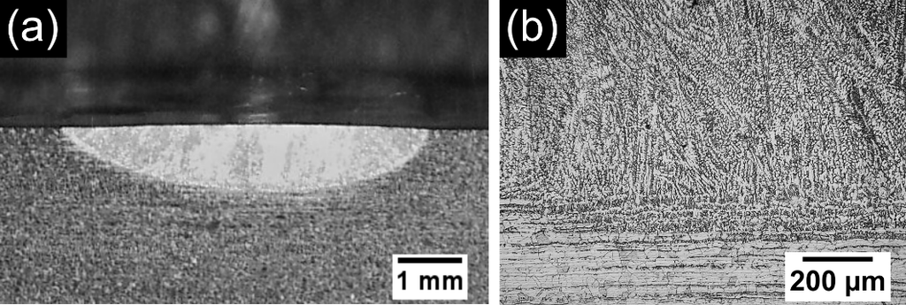

**Figura 1.** Cordão de solda realizado com corrente de soldagem de 100 A: (a) macrografia e (b) micrografia da raiz do cordão de solda

**Declaração da contribuição dos autores**

Neste campo deve ser informado os nomes de todos os autores seguidos das suas respectivas contribuições. Para a definição das contribuições, a Revista Soldagem & Inspeção recomenda o [CRediT](https://casrai.org/credit/) (Contributor Roles Taxonomy).

**Referências Bibliográficas**

As referências devem ser listadas em ordem correspondente ao sistema numérico adotados nas citações. Os autores devem privilegiar a norma Vancouver. Como exemplo de lista de referências tem-se:

*Artigos de periódico*

[1] Voigt AL, da Cunha TV, Díaz VV. Low cost methodology for images recording of arc welding. Rev. soldag. insp. 2017;22(4).

*Teses, Dissertações e Trabalhos de Conclusão de Curso*

[2] Oliveira E. Ethanol flushing of gasoline residuals: microscale and field scale experiments [Tese de Doutorado]. Waterloo: University of Waterloo; 1997.

*Livros*

[3] Marques, PV, Modenesi, JP, Bracarense, AQ. Soldagem: fundamentos e tecnologia. Belo Horizonte: Editora UFMG; 2009.

*Websites*

[4] ABB. Top 10 robotics firsts from ABB. ABB Conversations; 2013 [acesso em 26 maio 2021]. Available at: [https://www.abb-conversations.com/2013/11/top-10-robotics-firsts-from-abb/](https://www.abbconversations.com/2013/11/top-10-robotics-firsts-from-abb/).

*Patente*

[5] Birindelli RF, inventor; 3M Innovative Properties Company, assignee. Disposição construtiva apliacada em dispositivo protetor auditivo. Brazil patent BR MU 8201717-4. 2002 Feb 19.

*Normas Técnicas*

[6] Associação Brasileira de Normas Técnicas. ABNT NBR ISO 12836: odontologia: dispositivos para sistemas CAD/CAM para restaurações dentárias indiretas: métodos de ensaio para avaliação de exatidão. Rio de Janeiro: ABNT; 2017. 14 p.

**Associação Brasileira de Soldagem** Rua Dr Guilherme Bannitz, 126 conj 42, 04532-060 - São Paulo/SP Brasil, Tel.: (55 11) 3045 5040, Fax: (55 11) 3045 8578 - São Paulo - SP - Brazil  
**E-mail:** abs@abs-soldagem.org.br